# Using dittoSeq to visualize (sc)RNAseq data

Daniel Bunis

daniel.bunis@ucsf.edu

May 25th, 2021

#### Package

dittoSeq 1.8.0

# 1 Introduction

dittoSeq is a tool built to enable analysis and visualization of single-cell and bulk RNA-sequencing data by novice, experienced, and color-blind coders. Thus, it provides many useful visualizations, which all utilize red-green color-blindness optimized colors by default, and which allow sufficient customization, via discrete inputs, for out-of-the-box creation of publication-ready figures.

For single-cell data, dittoSeq works directly with data pre-processed in other popular packages (Seurat, scater, scran, …). For bulk RNAseq data, dittoSeq’s import functions will convert bulk RNAseq data of various different structures into a set structure that dittoSeq helper and visualization functions can work with. So ultimately, dittoSeq includes universal plotting and helper functions for working with (sc)RNAseq data processed and stored in these formats:

Single-Cell:

- SingleCellExperiment
- Seurat (v2 onwards)

Bulk:

- SummarizedExperiment (the general Bioconductor Seq-data storage system)
- DESeqDataSet (DESeq2 package output)
- DGEList (edgeR package output)

For bulk data, or if your data is currently not analyzed, or simply not in one of these structures, you can still pull it in to the SingleCellExperiment structure that dittoSeq works with using the `importDittoBulk` function.

## 1.1 Color-blindness friendliness:

The default colors of this package are red-green color-blindness friendly. To make it so, I used the suggested colors from (Wong 2011) and adapted them slightly by appending darker and lighter versions to create a 24 color vector. All plotting functions use these colors, stored in `dittoColors()`, by default.

Additionally:

- Shapes displayed in the legends are generally enlarged as this can be almost as helpful as the actual color choice for colorblind individuals.
- When sensible, dittoSeq functions have a shape.by input for having groups displayed through shapes rather than color. (But note: even as a red-green color impaired individual myself writing this vignette, I recommend using color and I generally only use shapes for showing additional groupings.)
- dittoDimPlots can be generated with letters overlaid (set do.letter = TRUE)
- The `Simulate` function allows a cone-typical individual to see what their dittoSeq plots might look like to a colorblind individual.

## 1.2 Disclaimer

Code used here for dataset processing and normalization should not be seen as a suggestion of the proper methods for performing such steps. dittoSeq is a visualization tool, and my focus while developing this vignette has been simply creating values required for providing “pretty-enough” visualization examples.

# 2 Installation

dittoSeq is available through Bioconductor.

```r
# Install BiocManager if needed
if (!requireNamespace("BiocManager", quietly = TRUE))
    install.packages("BiocManager")

# Install dittoSeq
BiocManager::install("dittoSeq")
```

# 3 Quick-Reference: Seurat<=>dittoSeq

As of May 25th, 2021, Seurat-v4.0.2 & dittoSeq v1.4.1

Because often users will be familiar with Seurat already, so this may be 90% of what you may need!

## 3.1 Functions

| Seurat Viz Function(s) | dittoSeq Equivalent(s) |
| --- | --- |
| DimPlot/ (I)FeaturePlot / UMAPPlot / etc. | dittoDimPlot / multi_dittoDimPlot |
| VlnPlot / RidgePlot | dittoPlot / multi_dittoPlot |
| DotPlot | dittoDotPlot |
| FeatureScatter / GenePlot | dittoScatterPlot |
| DoHeatmap | dittoHeatmap* |
| [No Seurat Equivalent] | dittoBarPlot / dittoFreqPlot |
| [No Seurat Equivalent] | dittoDimHex / dittoScatterHex |
| [No Seurat Equivalent] | dittoPlotVarsAcrossGroups |
| SpatialDimPlot, SpatialFeaturePlot, etc. | dittoSpatial (coming soon!) |

*Not all dittoSeq features exist in Seurat counterparts, and occasionally the same is true in the reverse.

## 3.2 Inputs

See reference below for the equivalent names of major inputs

Seurat has had inconsistency in input names from version to version. dittoSeq drew some of its parameter names from previous Seurat-equivalents to ease cross-conversion, but continuing to blindly copy their parameter standards will break people’s already existing code. Instead, dittoSeq input names are guaranteed to remain consistent across versions, unless a change is required for useful feature additions.

| Seurat Viz Input(s) | dittoSeq Equivalent(s) |
| --- | --- |
| `object` | SAME |
| `features` | `var` / `vars` (generally the 2nd input, so name not needed!) OR `genes` & `metas` for dittoHeatmap() |
| `cells` (cell subsetting is not always available) | `cells.use` (consistently available) |
| `reduction` & `dims` | `reduction.use` & `dim.1`, `dim.2` |
| `pt.size` | `size` (or `jitter.size`) |
| `group.by` | SAME |
| `split.by` | SAME |
| `shape.by` | SAME and also available in dittoPlot() |
| `fill.by` | `color.by` (can be used to subset `group.by` further!) |
| `assay` / `slot` | SAME |
| `order` = logical | `order` but = “unordered” (default), “increasing”, or “decreasing” |
| `cols` | `color.panel` for discrete OR `min.color`, `max.color` for continuous |
| `label` & `label.size` & `repel` | `do.label` & `labels.size` & `labels.repel` |
| `interactive` | `do.hover` = via plotly conversion |
| [Not in Seurat] | `data.out`, `do.raster`, `do.letter`, `do.ellipse`, `add.trajectory.lineages` and others! |

# 4 Setup: Some simple preprocessing

```r
## Download Data
library(scRNAseq)
sce <- BaronPancreasData()
# Trim to only 5 of the cell types for simplicity of vignette
sce <- sce[,sce$label %in% c(
    "acinar", "beta", "gamma", "delta", "ductal")]
```

Now that we have a single-cell dataset loaded, we are ready to go. All functions work for either Seurat or SCE encapsulated single-cell data.

But to make full use of dittoSeq, we should really have this data log-normalized, and we should run dimensionality reduction and clustering.

```r
## Some Quick Pre-processing
# Normalization.
library(scater)
sce <- logNormCounts(sce)

# Feature selection.
library(scran)
dec <- modelGeneVar(sce)
hvg <- getTopHVGs(dec, prop=0.1)

# PCA & UMAP
library(scater)
set.seed(1234)
sce <- runPCA(sce, ncomponents=25, subset_row=hvg)
sce <- runUMAP(sce, pca = 10)

# Clustering.
library(bluster)
sce$cluster <- clusterCells(sce, use.dimred='PCA',
    BLUSPARAM=NNGraphParam(cluster.fun="louvain"))

# Add some metadata common to Seurat objects
sce$nCount_RNA <- colSums(counts(sce))
sce$nFeature_RNA <- colSums(counts(sce)>0)
sce$percent.mito <- colSums(counts(sce)[grep("^MT-", rownames(sce)),])/sce$nCount_RNA

sce
```

```
## class: SingleCellExperiment
## dim: 20125 5416
## metadata(0):
## assays(2): counts logcounts
## rownames(20125): A1BG A1CF ... ZZZ3 pk
## rowData names(0):
## colnames(5416): human1_lib1.final_cell_0001 human1_lib1.final_cell_0002
##   ... human4_lib3.final_cell_0700 human4_lib3.final_cell_0701
## colData names(7): donor label ... nFeature_RNA percent.mito
## reducedDimNames(2): PCA UMAP
## mainExpName: NULL
## altExpNames(0):
```

Now we have a single-cell dataset loaded and analyzed as an SCE, but note: **All functions will work the same for single-cell data stored as either** **Seurat or SCE.**

# 5 Getting started

## 5.1 Single-cell RNAseq data

dittoSeq works natively with Seurat and SingleCellExperiment objects. Nothing special is needed. Just load in your data if it isn’t already loaded, then go!

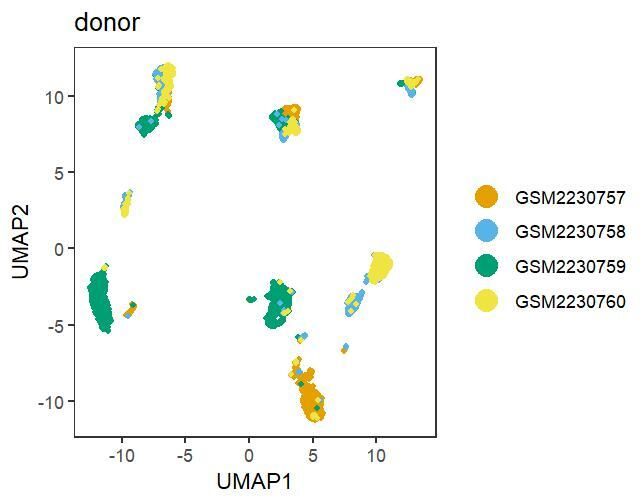

```r
library(dittoSeq)
dittoDimPlot(sce, "donor")
```

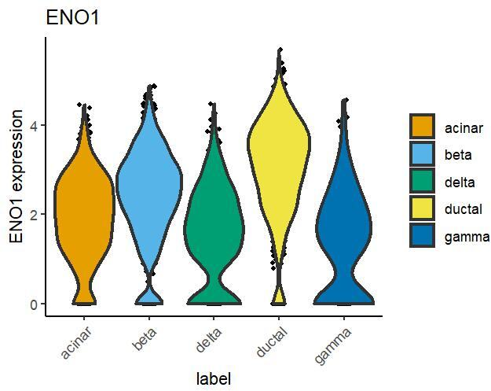

```r
dittoPlot(sce, "ENO1", group.by = "label")
```

```r
dittoBarPlot(sce, "label", group.by = "donor")
```

[output not shown]

## 5.2 Bulk RNAseq data

```r
# First, we'll just make some mock expression and conditions data
exp <- matrix(rpois(20000, 5), ncol=20)
colnames(exp) <- paste0("donor", seq_len(ncol(exp)))
rownames(exp) <- paste0("gene", seq_len(nrow(exp)))
logexp <- logexp <- log2(exp + 1)

pca <- matrix(rnorm(20000), nrow=20)

conditions <- factor(rep(1:4, 5))
sex <- c(rep("M", 9), rep("F", 11))
```

dittoSeq works natively with bulk RNAseq data stored as a SummarizedExperiment object, and this includes data analyzed with DESeq2.

```r
library(SummarizedExperiment)
bulkSE <- SummarizedExperiment(
    assays = list(counts = exp,
             logcounts = logexp),
    colData = data.frame(conditions = conditions,
                          sex = sex)
)
```

Alternatively, or for bulk data stored in other forms, such as a DGEList or as raw matrices, one can use the `importDittoBulk()` function to convert it into the SingleCellExperiment structure.

Some brief details on this structure: The SingleCellEExperiment class is very similar to the base SummarizedExperiment class, but with room added for storing pre-calculated dimensionality reductions.

```r
# dittoSeq import which allows
bulkSCE <- importDittoBulk(
    # x can be a DGEList, a DESeqDataSet, a SummarizedExperiment,
    #   or a list of data matrices
    x = list(counts = exp,
             logcounts = logexp),
    # Optional inputs:
    #   For adding metadata
    metadata = data.frame(conditions = conditions,
                          sex = sex),
    #   For adding dimensionality reductions
    reductions = list(pca = pca)
    )
```

Metadata and dimensionality reductions can be added either directly within the `importDittoBulk()` function via the `metadata` and `reductions` inputs, as above, or separately afterwards:

```r
# Add metadata (metadata can alternatively be added in this way)
bulkSCE$conditions <- conditions
bulkSCE$sex <- sex

# Add dimensionality reductions (can alternatively be added this way)
bulkSCE <- addDimReduction(
    object = bulkSCE,
    # (We aren't actually calculating PCA here.)
    embeddings = pca,
    name = "pca",
    key = "PC")
```

Making plots for bulk data then operates similarly as for single-cell except for one slight caveat for SummarizedExperiment objects

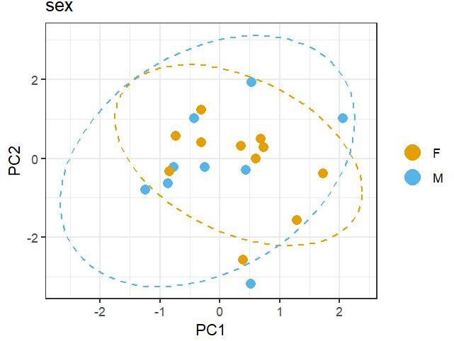

```r
library(dittoSeq)
dittoDimPlot(bulkSCE, "sex", size = 3, do.ellipse = TRUE)
```

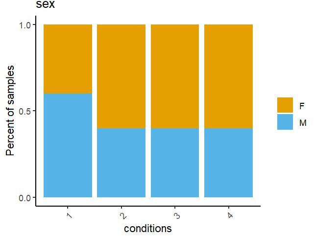

```r
dittoBarPlot(bulkSCE, "sex", group.by = "conditions")
```

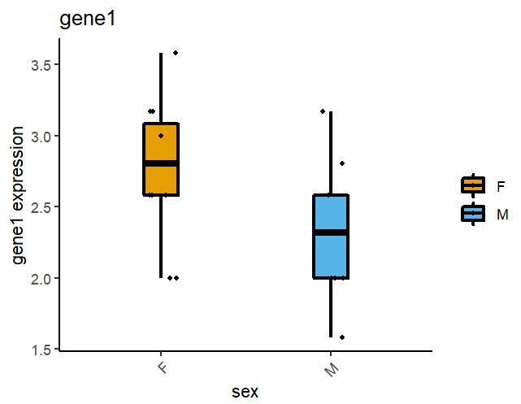

```r
dittoBoxPlot(bulkSCE, "gene1", group.by = "sex")
```

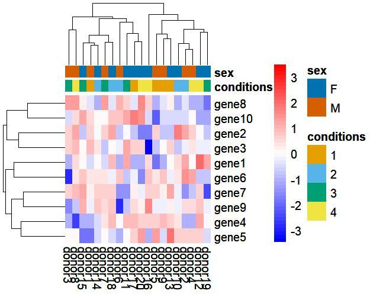

```r
dittoHeatmap(bulkSCE, getGenes(bulkSCE)[1:10],
    annot.by = c("conditions", "sex"))
```

```r
# SummarizedExperiment dim-plots:
dittoDimPlot(
    bulkSE,"sex", size = 3, do.ellipse = TRUE,
    reduction.use = pca
    )
```

[output not shown]

#### 5.2.0.1 Additional details on bulk data import:

By default, sample-associated data from original objects are retained. But metadata provided to the `metadata` input will replace any similarly named slots from the original object. The `combine_metadata` input can additionally be used to turn retention of previous metadata slots off.

DGEList note: The import function attempts to pull in all information stored in common DGEList slots ($counts, $samples, $genes, $AveLogCPM, $common.dispersion, $trended.dispersion, $tagwise.dispersion, and $offset), but any other slots are ignored.

When providing `x` a list of a single or multiple matrices, it is recommended that matrices containing raw feature counts data be named `counts`, log-normalized counts data be named `logcounts`, and otherwise normalized data, be named `normcounts`. Then you can give the `assay` input of dittoSeq functions “counts” to point towards the raw data for example. This is not a requirement, but the default assay used in dittoSeq functions will be one of: 1) “logcounts” if it exists, 2) “normcounts” if it exists, 3) “counts” if it exists, or 4) whatever the first assay is in the object.

The SCE object created by `importDittoBulk()` will contain an internal metadata slot which tells dittoSeq that the object holds bulk data. Knowledge of whether a dataset is single-cell versus bulk is used to aadjust parameter defaults for in few functions; “samples” vs “cells” in the y-axis label of `dittoBarPlot()`, and whether cells (no) versus samples (yes) should be clustered by default for `dittoHeatmap()`.

# 6 Helper Functions

dittoSeq’s helper functions make it easy to determine the metadata, gene, and dimensionality reduction options for plotting.

## 6.1 Metadata

```r
# Retrieve all metadata slot names
getMetas(sce)
```

```
## [1] "donor"        "label"        "sizeFactor"   "cluster"      "nCount_RNA"
## [6] "nFeature_RNA" "percent.mito"
```

```r
# Query for the presence of a metadata slot
isMeta("nCount_RNA", sce)
```

```
## [1] TRUE
```

```r
# Retrieve metadata values:
meta("label", sce)[1:10]
```

```
## human1_lib1.final_cell_0001 human1_lib1.final_cell_0002
##                    "acinar"                    "acinar"
## human1_lib1.final_cell_0003 human1_lib1.final_cell_0004
##                    "acinar"                    "acinar"
## human1_lib1.final_cell_0005 human1_lib1.final_cell_0006
##                    "acinar"                    "acinar"
## human1_lib1.final_cell_0007 human1_lib1.final_cell_0008
##                      "beta"                    "acinar"
## human1_lib1.final_cell_0009 human1_lib1.final_cell_0010
##                    "acinar"                    "acinar"
```

```r
# Retrieve unique values of a metadata
metaLevels("label", sce)
```

```
## [1] "acinar" "beta"   "delta"  "ductal" "gamma"
```

## 6.2 Genes/Features

```r
# Retrieve all gene names
getGenes(sce)[1:10]
```

```
##  [1] "A1BG"   "A1CF"   "A2M"    "A2ML1"  "A4GALT" "A4GNT"  "AA06"   "AAAS"
##  [9] "AACS"   "AACSP1"
```

```r
# Query for the presence of a gene(s)
isGene("CD3E", sce)
```

```
## [1] TRUE
```

```r
isGene(c("CD3E","ENO1","INS","non-gene"), sce, return.values = TRUE)
```

```
## [1] "CD3E" "ENO1" "INS"
```

```r
# Retrieve gene expression values:
gene("ENO1", sce)[1:10]
```

```
## human1_lib1.final_cell_0001 human1_lib1.final_cell_0002
##                    2.168578                    2.013074
## human1_lib1.final_cell_0003 human1_lib1.final_cell_0004
##                    1.551996                    1.234598
## human1_lib1.final_cell_0005 human1_lib1.final_cell_0006
##                    3.064644                    1.802279
## human1_lib1.final_cell_0007 human1_lib1.final_cell_0008
##                    2.301963                    1.066135
## human1_lib1.final_cell_0009 human1_lib1.final_cell_0010
##                    2.398596                    1.450935
```

## 6.3 Reductions

```r
# Retrieve all dimensionality reductions
getReductions(sce)
```

```
## [1] "PCA"  "UMAP"
```

These are what can be provided to `reduction.use` for `dittoDimPlot()`.

## 6.4 Characteristic: Bulk versus single-cell

Because dittoSeq utilizes the SingleCellExperiment structure to handle some bulk RNAseq data, there is a getter and setter for the internal metadata which tells dittoSeq functions which resolution of data a target SCE holds.

```r
# Getter
isBulk(sce)
```

```
## [1] FALSE
```

```r
isBulk(bulkSCE)
```

```
## [1] TRUE
```

```r
# Setter
mock_bulk <- setBulk(sce) # to bulk
isBulk(sce)
```

```
## [1] FALSE
```

```r
mock_sc <- setBulk(bulkSCE, set = FALSE) # to single-cell
isBulk(bulkSCE)
```

```
## [1] TRUE
```

# 7 Visualizations

There are many different types of dittoSeq visualizations. Each has intuitive defaults which allow creation of immediately usable plots. Each also has many additional tweaks available through discrete inputs that can help ensure you can create precisely-tuned, deliberately-labeled, publication-quality plots out-of-the-box.

## 7.1 dittoDimPlot & dittoScatterPlot

These show cells/samples data overlaid on a scatter plot, with the axes of `dittoScatterPlot()` being gene expression or metadata data and with the axes of `dittoDimPlot()` being dimensionality reductions like tsne, pca, umap or similar.

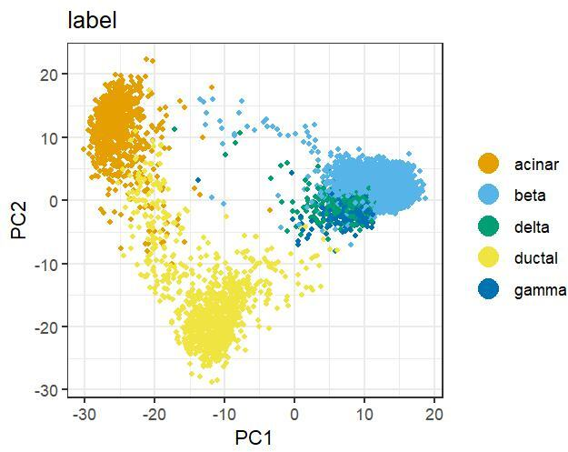

```r
dittoDimPlot(sce, "label", reduction.use = "PCA")
```

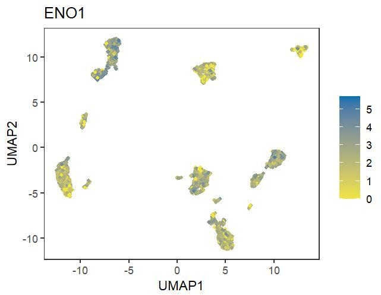

```r
dittoDimPlot(sce, "ENO1")
```

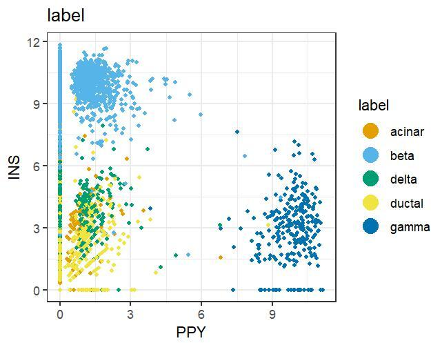

```r
dittoScatterPlot(
    object = sce,
    x.var = "PPY", y.var = "INS",
    color.var = "label")
```

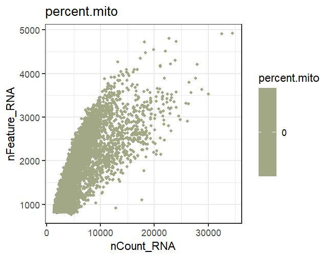

```r
dittoScatterPlot(
    object = sce,
    x.var = "nCount_RNA", y.var = "nFeature_RNA",
    color.var = "percent.mito")
```

### 7.1.1 Additional features

Various additional features can be overlaid on top of these plots. Adding each is controlled by an input that starts with `add.` or `do.` such as:

- `do.label`
- `do.ellipse`
- `do.letter`
- `do.contour`
- `do.hover`
- `add.trajectory.lineages`
- `add.trajectory.curves`

Additional inputs that apply to and adjust these features will then start with the XXXX part that comes after `add.XXXX` or `do.XXXX`, as exemplified below. (Tab-completion friendly!)

A few examples:

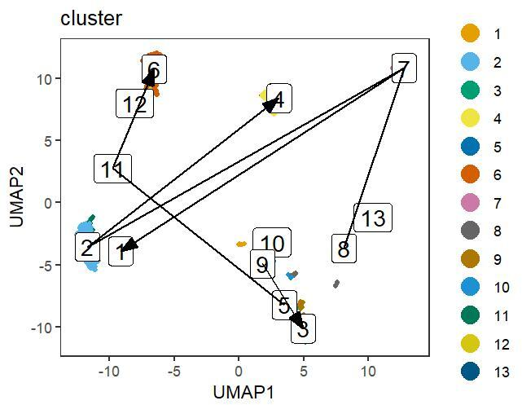

```r
dittoDimPlot(sce, "cluster",

             do.label = TRUE,
             labels.repel = FALSE,

             add.trajectory.lineages = list(
                 c("9","3"),
                 c("8","7","2","4"),
                 c("8","7","1"),
                 c("5","11","6"),
                 c("10","0")),
             trajectory.cluster.meta = "cluster")
```

## 7.2 dittoDimHex & dittoScatterHex

Similar to the “Plot” versions, these show cells/samples data overlaid on a scatter plot, with the axes of `dittoScatterHex()` being gene expression or metadata or some other data, and with the axes of `dittoDimHex()` being dimensionality reductions like tsne, pca, umap or similar.

The plot area is then broken into hexagonal bins and data is presented as summaries of cells/samples within each of those bins.

The minimal functions will summarize density of cells/samples only using color.

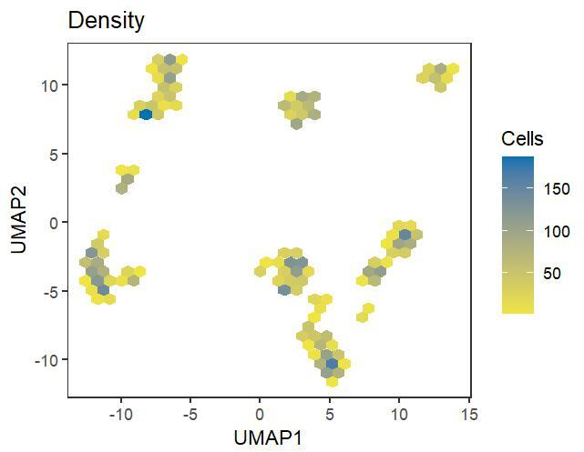

```r
dittoDimHex(sce)
```

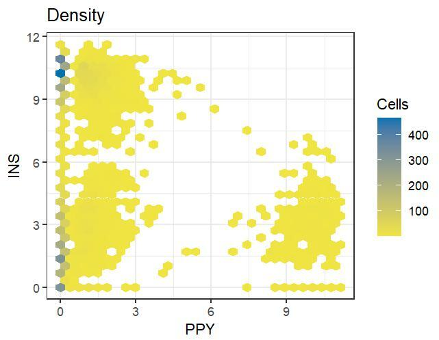

```r
dittoScatterHex(sce,
    x.var = "PPY", y.var = "INS")
```

An additional feature can be provided to have that data be summarized in addition to density. Density will then be represented with opacity, while color is used for the additional feature. The `color.method` input then controls how data within the bins are represented.

NOTE: It is important to note that as soon as differing opacity is added, the color-blindness friendliness of dittoSeq’s default colors is no longer guaranteed.

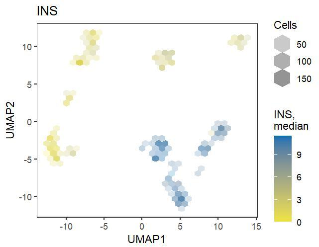

```r
dittoDimHex(sce, "INS")
```

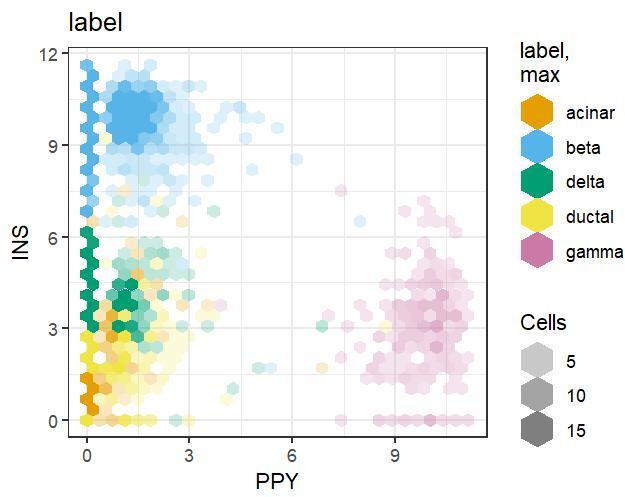

```r
dittoScatterHex(
    object = sce,
    x.var = "PPY", y.var = "INS",
    color.var = "label",
    colors = c(1:4,7), max.density = 15)
```

### 7.2.1 Summary function control

`color.method` controls how data within the bins are represented in colors. It is provided a string, but how that string is utilized depends on the type of target data.

For discrete data, you can provide either `"max"` (the default) to display the predominant grouping of the bins, or `"max.prop"` to display the proportion of cells in the bins that belong to the maximal grouping.

For continuous data, any string signifying a function [that summarizes a numeric vector input into with a single numeric value] can be provided. The default is `"median"`, but other useful options are `"sum"`, `"mean"`, `"sd"`, or `"mad"`.

### 7.2.2 Additional features

Similar to dittoDimPlot and dittoScatterPlot, various additional layers are built in and their addition is controlled by inputs that starts with `add.` or `do.` such as:

- `do.label`
- `do.ellipse`
- `do.contour`
- `add.trajectory.lineages`
- `add.trajectory.curves`

Additional inputs that apply to and adjust these features will then start with the XXXX part that comes after `add.XXXX` or `do.XXXX`, as exemplified below. (Tab-completion friendly!)

## 7.3 dittoPlot (and dittoRidgePlot + dittoBoxPlot wrappers)

These display *continuous* cells/samples’ data on a y-axis (or x-axis for ridgeplots) grouped on the x-axis by sample, age, condition, or any discrete grouping metadata. Data can be represented with violin plots, box plots, individual points for each cell/sample, and/or ridge plots. The `plots` input controls which data representations are used. The `group.by` input controls how the data are grouped in the x-axis. And the `color.by` input controls the colors that fill in violin, box, and ridge plots.

`dittoPlot()` is the main function, but `dittoRidgePlot()` and `dittoBoxPlot()` are wrappers which essentially just adjust the default for the `plots` input from c(“jitter”, “vlnplot”) to c(“ridgeplot”) or c(“boxplot”,“jitter”), respectively.

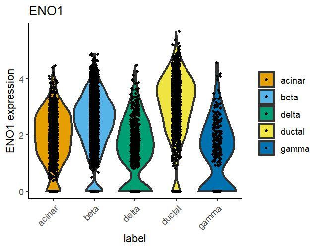

```r
dittoPlot(sce, "ENO1", group.by = "label",
    plots = c("vlnplot", "jitter"))
```

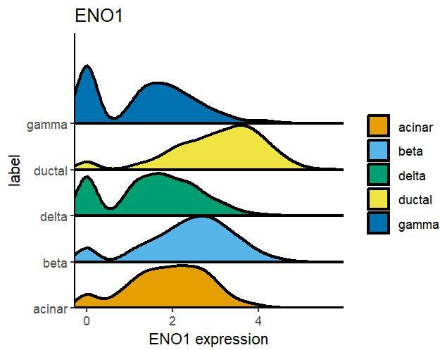

```r
dittoRidgePlot(sce, "ENO1", group.by = "label")
```

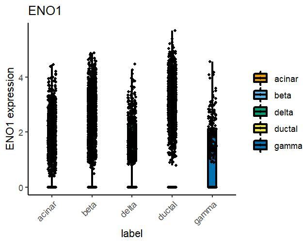

```r
dittoBoxPlot(sce, "ENO1", group.by = "label")
```

### 7.3.1 Adjustments to data representations

Tweaks to the individual data representation types can be made with discrete inputs, all of which start with the representation types’ name. For example…

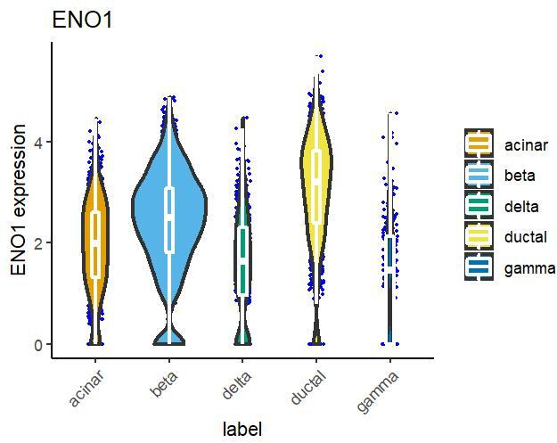

```r
dittoPlot(sce, "ENO1", group.by = "label",
    plots = c("jitter", "vlnplot", "boxplot"), # <- order matters

    # change the color and size of jitter points
    jitter.color = "blue", jitter.size = 0.5,

    # change the outline color and width, and remove the fill of boxplots
    boxplot.color = "white", boxplot.width = 0.1,
    boxplot.fill = FALSE,

    # change how the violin plot widths are normalized across groups
    vlnplot.scaling = "count"
    )
```

## 7.4 dittoBarPlot & dittoFreqPlot

A couple of very handy visualizations missing from some other major single-cell visualization toolsets, these functions quantify and display frequencies of clusters or cell types (or other discrete data) per sample (or other discrete groupings). Such visualizations are quite useful for QC-ing clustering for batch effects and generally assessing cell type fluctuations.

For both, data can be represented as percentages or counts, and this is controlled by the `scale` input.

```r
# dittoBarPlot
dittoBarPlot(sce, "label", group.by = "donor")
```

[output not shown]

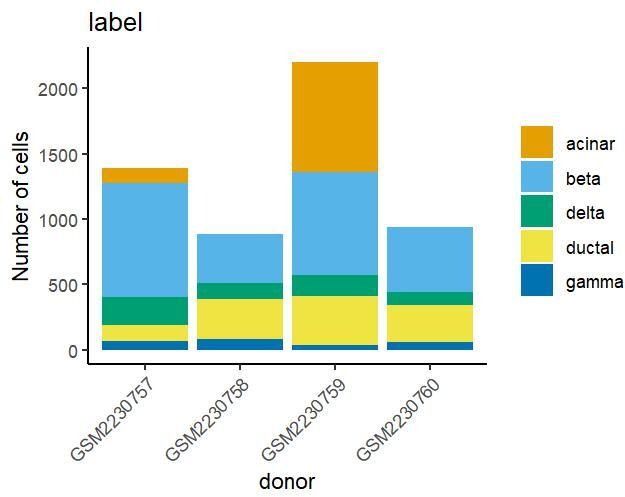

```r
dittoBarPlot(sce, "label", group.by = "donor",
    scale = "count")
```

dittoFreqPlot separates each cell type into its own facet, and thus puts more emphasis on individual cells. An additional `sample.by` input controls splitting of cells within `group.by`-groups into individual samples.

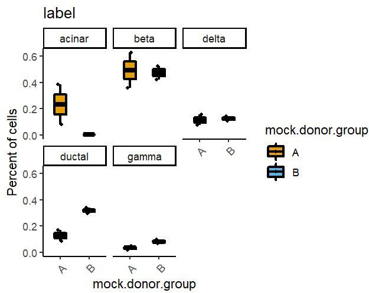

```r
# dittoFreqPlot
sce$mock.donor.group <- ifelse(sce$donor %in% unique(sce$donor)[1:2], "A", "B")
dittoFreqPlot(sce, "label",
    sample.by = "donor", group.by = "mock.donor.group")
```

## 7.5 dittoHeatmap

This function is essentially a wrapper for generating heatmaps with pheatmap, but with the same automatic, user-friendly, data extraction, (subsetting,) and metadata integration common to other dittoSeq functions.

For large, many cell, single-cell datasets, it can be necessary to turn off clustering by cells in generating the heatmap because the process is very memory intensive. As an alternative, dittoHeatmap offers the ability to order columns in functional ways using the `order.by` input. This input will default to the first annotation provided to `annot.by` for single cell datasets, but can also be controlled separately.

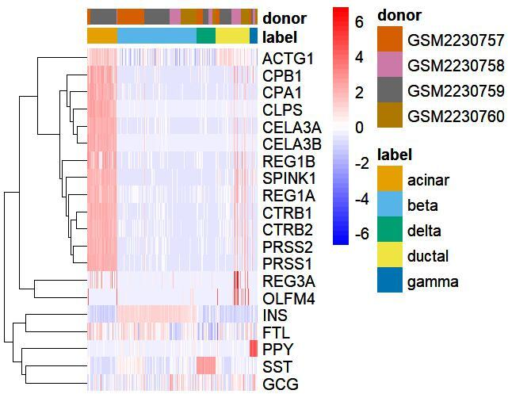

```r
# Pick Genes
genes <- c("SST", "REG1A", "PPY", "INS", "CELA3A", "PRSS2", "CTRB1",
    "CPA1", "CTRB2" , "REG3A", "REG1B", "PRSS1", "GCG", "CPB1",
    "SPINK1", "CELA3B", "CLPS", "OLFM4", "ACTG1", "FTL")

# Annotating and ordering cells by some meaningful feature(s):
dittoHeatmap(sce, genes,
    annot.by = c("label", "donor"))
```

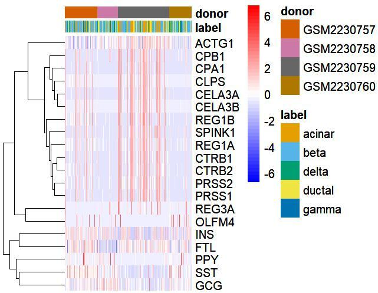

```r
dittoHeatmap(sce, genes,
    annot.by = c("label", "donor"),
    order.by = "donor")
```

`scaled.to.max = TRUE` will normalize all expression data to the max expression of each gene [0,1], which is often useful for zero-enriched single-cell data.

`show_colnames`/`show_rownames` control whether cell/gene names will be shown. (`show_colnames` default is TRUE for bulk, and FALSE for single-cell.)

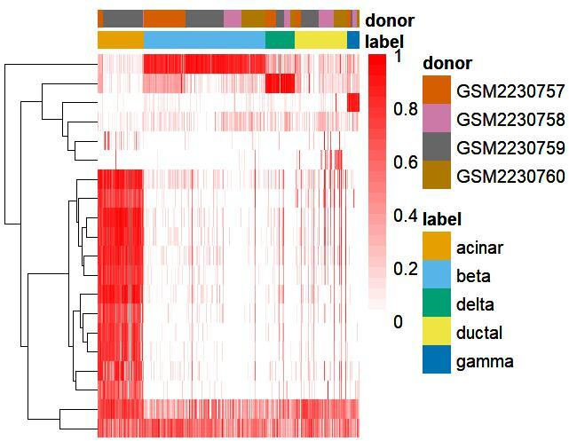

```r
# Add annotations
dittoHeatmap(sce, genes,
    annot.by = c("label", "donor"),
    scaled.to.max = TRUE,
    show_colnames = FALSE,
    show_rownames = FALSE)
```

A subset of the supplied genes can be given to the `highlight.features` input to have names shown for just these genes.

The heatmap can also be rendered by the ComplexHeatmap package, rather than by the pheatmap package (default), by setting `complex` to TRUE. This package offers a wide variety of distinct plot customization, including rasterization when the heatmap would be too complex for editing software like Illustrator.

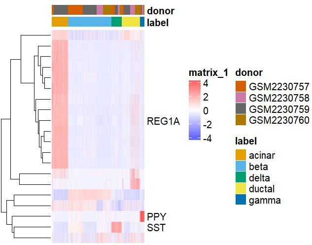

```r
# Highlight certain genes
dittoHeatmap(sce, genes, annot.by = c("label", "donor"),
    highlight.features = genes[1:3],
    complex = TRUE)
```

Additional tweaks can be added through other built in inputs or by providing additional inputs that get passed along to pheatmap::pheatmap (see `?pheatmap`) or to ComplexHeatmap::pheatmap (see `?ComplexHeatmap::pheatmap` and `?ComplexHeatmap::Heatmap` on which the former function relies.)

## 7.6 Multi-Plotters

These create either multiple plots or create plots that summarize data for multiple variables all in one plot. They make it easier to create summaries for many genes or many cell types without the need for writing loops.

Some setup for these, let’s roughly pick out the markers of delta cells in this data set

```r
# seurat <- as.Seurat(sce)
# Idents(seurat) <- "label"
# delta.marker.table <- FindMarkers(seurat, ident.1 = "delta")
# delta.genes <- rownames(delta.marker.table)[1:20]
# Idents(seurat) <- "seurat_clusters"

delta.genes <- c(
    "SST", "RBP4", "LEPR", "PAPPA2", "LY6H",
    "CBLN4", "GPX3", "BCHE", "HHEX", "DPYSL3",
    "SERPINA1", "SEC11C", "ANXA2", "CHGB", "RGS2",
    "FXYD6", "KCNIP1", "SMOC1", "RPL10", "LRFN5")
```

### 7.6.1 dittoDotPlot

A very succinct representation that is useful for showing differences between groups. The plot uses differently colored and sized dots to summarizes both expression level (color) and percent of cells/samples with non-zero expression (size) for multiple genes (or values of metadata) within different groups of cells/samples.

By default, expression values for all groups are centered and scaled to ensure a similar range of values for all `vars` displayed and to emphasize differences between groups.

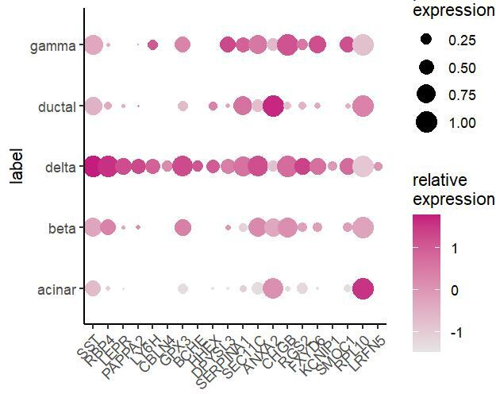

```r
dittoDotPlot(sce, vars = delta.genes, group.by = "label")
```

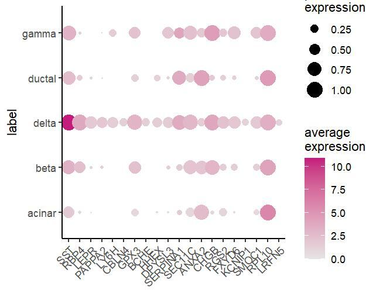

```r
dittoDotPlot(sce, vars = delta.genes, group.by = "label",
    scale = FALSE)
```

### 7.6.2 multi_dittoPlot & dittoPlotVarsAcrossGroups

`multi_dittoPlot()` creates dittoPlots for multiple genes or metadata, one plot each.

`dittoPlotVarsAcrossGroups()` creates a dittoPlot-like representation where instead of representing samples/cells as in typical dittoPlots, each data point instead represents a gene (or metadata). More specifically, the average expression, within each x-grouping, of a gene (or value of a metadata).

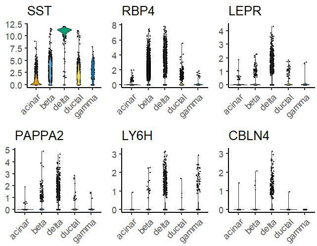

```r
multi_dittoPlot(sce, delta.genes[1:6], group.by = "label",
    vlnplot.lineweight = 0.2, jitter.size = 0.3)
```

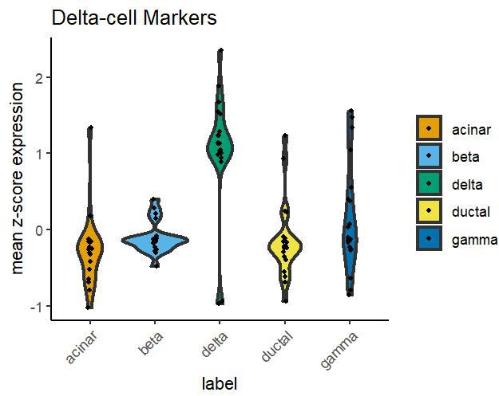

```r
dittoPlotVarsAcrossGroups(sce, delta.genes, group.by = "label",
    main = "Delta-cell Markers")
```